# API - Importation geojson

Auteur·rice

Claude Grasland

Date de publication

2025-02-11

Le but de ce dernier sous-chapitre est d’approfondir les méthodes de recueil de données lorsque celles-ci comportent une information géographique sur la localisation des objets étudiés. Nous allons donc charger non plus seulement des tableaux statistiques mais aussi de l’information géographique décrivant la localisation de poins, lignes ou polygones. Cela implique deux nouveautés :

- l’utilisation du format de transfert GEOJSON qui est une extension de JSON au cas de l’information géographique et qui est importable dans R avec le pakage **spatial features (sf)**.
- la cartographie rapide d’un fichier sf en mode statique ou dynamique à l’aide du package **tmap**.

Nous verrons en détail l’utilisation des données géographiques dans les chapitres ultérieurs et on se bornera ici à analyser comment recueillir cette information à l’aide d’une API. On va récupérer cette fois-ci des données au format geojson.

On charge les packages utiles :

```r
knitr::opts_chunk$set(echo = TRUE, warning= FALSE, message = FALSE, error=FALSE)

## Affichage de tableaux
library(knitr)

## Requêtes web
library(httr)
library(jsonlite)

# Cartographie rapide
library(sf)
library(tmap)

## Tidyverse & co
library(dplyr, warn.conflicts = T, quietly = T)
```

### 1. Récupération par lien de télécgargement

Nous avons récupéré un lien de téléchargement sur le site public.opendatasoft mais en utilisant le format geojson

```r
link<-"https://public.opendatasoft.com/api/explore/v2.1/catalog/datasets/indice-de-defavorisation-sociale-fdep-par-iris/exports/geojson?lang=fr&refine=c_nom_com%3A%22SUCY-EN-BRIE%22&timezone=Europe%2FBerlin"
map<-st_read(link,quiet = T)
class(map)
```

```
[1] "sf"         "data.frame"
```

On voit que le fichier possède maintenant un attribut *sf* (spatial features) en plus de l’attribut *data.frame*

### 2. Examen des variables

```r
summary(map)
```

```
 geo_point_2d          t1_com            t1_p09_pop    c_dcomiris
 Length:11          Length:11          Min.   :1659   Length:11
 Class :character   Class :character   1st Qu.:2152   Class :character
 Mode  :character   Mode  :character   Median :2345   Mode  :character
                                       Mean   :2357
                                       3rd Qu.:2631
                                       Max.   :3040
   t1_txbac09      t1_rev_med     c_typ_iris         c_nom_iris
 Min.   :34.93   Min.   :15379   Length:11          Length:11
 1st Qu.:45.02   1st Qu.:22561   Class :character   Class :character
 Median :53.82   Median :26249   Mode  :character   Mode  :character
 Mean   :51.38   Mean   :25002
 3rd Qu.:58.10   3rd Qu.:28612
 Max.   :63.59   Max.   :32571
  c_nom_com           t1_txchom0       t1_txouvr0       nom_epci
 Length:11          Min.   : 4.246   Min.   : 7.070   Length:11
 Class :character   1st Qu.: 5.392   1st Qu.: 8.415   Class :character
 Mode  :character   Median : 6.681   Median :10.054   Mode  :character
                    Mean   : 7.661   Mean   :13.668
                    3rd Qu.: 8.514   3rd Qu.:19.649
                    Max.   :14.924   Max.   :25.548
   nom_dep            nom_reg                   geometry
 Length:11          Length:11          POLYGON      :11
 Class :character   Class :character   epsg:4326    : 0
 Mode  :character   Mode  :character   +proj=long...: 0
```

### 3. Cartographie statique

On réalise une carte statique avec le package tmap qui sera expliqué dans la suite du cours :

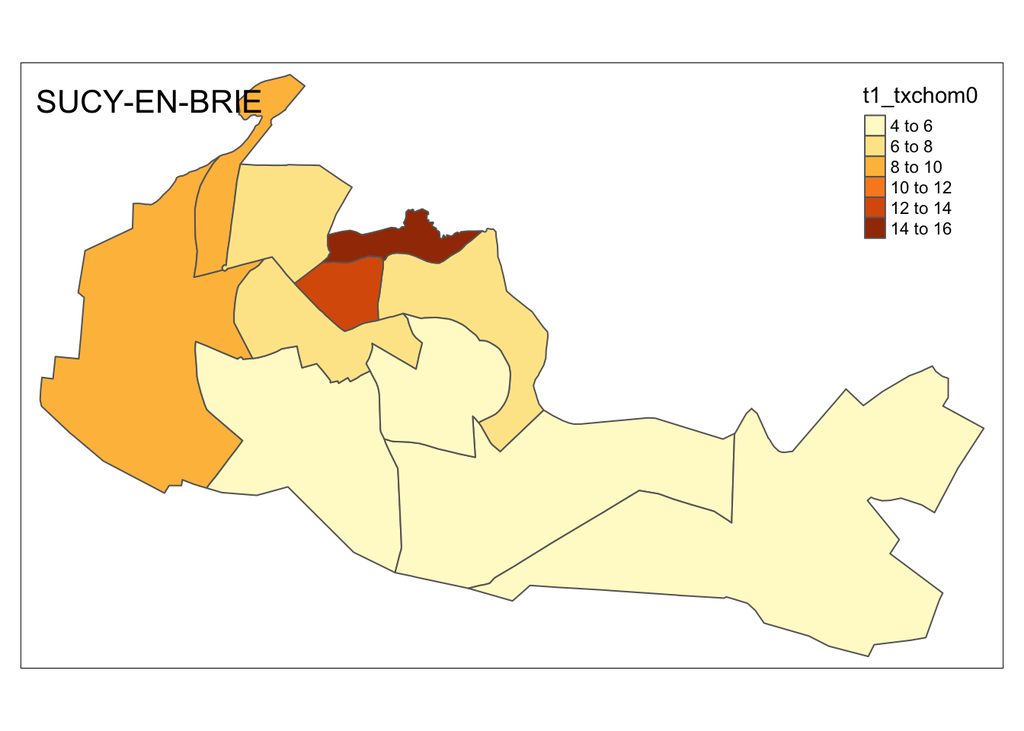

```r
tmap_mode("plot") +
tm_shape(map) +
  tm_polygons("t1_txchom0") +
   tm_legend(title="SUCY-EN-BRIE")
```

### 3. Cartographie dynamique

On réalise une carte dynamique avec le même package tmap en changeant juste le mode

```r
tmap_mode("view") +
tm_shape(map) +
  tm_polygons("t1_txchom0")  +
  tm_legend(title="SUCY-EN-BRIE")
```

[interactive chart not shown]

### 5. Rédaction d’une fonction

On peut maintenant écrire une fonction qui va dépendre de trois paramètre : - nom de la commune en majuscule - mode cartographique - variable.

```r
carto_com <- function(nomcom="SUCY-EN-BRIE", modecarto="plot", choixvar="t1_txchom0") {

link<-paste0("https://public.opendatasoft.com/api/explore/v2.1/catalog/datasets/indice-de-defavorisation-sociale-fdep-par-iris/exports/geojson?lang=fr&refine=c_nom_com%3A%22",nomcom,"%22&timezone=Europe%2FBerlin")

# Importation des données
map<-st_read(link, quiet=T)

# Affichage de la carte

tmap_mode(modecarto) +
 tm_shape(map) +
  tm_polygons(choixvar) +
  tm_legend(title=nomcom)

}
```

### 6. Test de la fonction

Pour tester notre fonction `carto_com()`, on prend l’exemple de la commune de Fontenay-sous-Bois dont on veut visualiser le revenu médian en mode statique

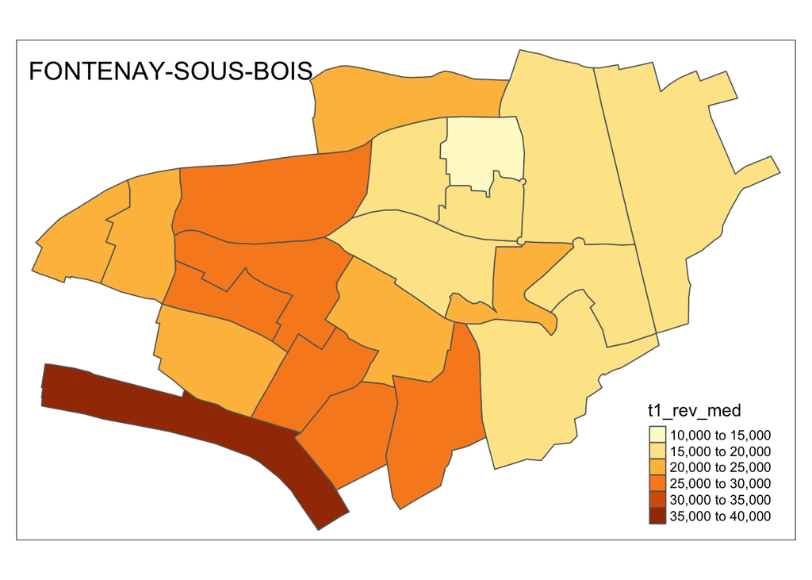

```r
carto_com("FONTENAY-SOUS-BOIS","plot","t1_rev_med")
```

On peut de la même manière visualiser le taux de chômage à Ivry-sur-Seine en mode dynamique :

```r
carto_com("IVRY-SUR-SEINE","view","t1_txchom0")
```

[interactive chart not shown]